# **Unsupervised Learning - FIFA 20**

# **Data Cleaning - Splitting into 2 groups**

# **Goalkeepers and Outflied Players**

If we divide the whole dataset into two groups - Outfield players and Goalkeepers then there would be no Null values as we can assign attributes relevant to a GK and outfield players.

This will also help us to align our model to our problem statement

### Data Set - Goalkeepers

```r
data_gk <- subset(x=fifa_data, subset= player_positions == "GK", select = c(sofifa_id,short_name,age,height_cm,weight_kg,overall,potential,value_eur,wage_eur,player_positions,international_reputation,weak_foot,skill_moves,gk_diving,gk_handling,gk_kicking,gk_reflexes,gk_speed,gk_positioning,attacking_crossing,attacking_finishing,attacking_heading_accuracy,attacking_short_passing,attacking_volleys,skill_dribbling,skill_curve,skill_fk_accuracy,skill_long_passing,skill_ball_control,movement_acceleration,movement_sprint_speed,movement_agility,movement_reactions,movement_balance,power_shot_power,power_jumping,power_stamina,power_strength,power_long_shots,mentality_aggression,mentality_interceptions,mentality_positioning,mentality_vision,mentality_penalties,mentality_composure,defending_marking,defending_standing_tackle,defending_sliding_tackle,goalkeeping_diving,goalkeeping_handling,goalkeeping_kicking,goalkeeping_positioning,goalkeeping_reflexes))
```

### Analysing the Goalkeeper Dataset - Head, Dimension and Glimpse

```r
head(data_gk)
dim(data_gk)
glimpse(data_gk)
```

[output not shown]

### Outfield Players Dataset

```r
data_outfield <- subset(x=fifa_data, subset= player_positions != "GK", select = c(sofifa_id,short_name,age,height_cm,weight_kg,overall,potential,value_eur,wage_eur,player_positions,international_reputation,weak_foot,skill_moves,pace,shooting,passing,dribbling,defending,physic,attacking_crossing,attacking_finishing,attacking_heading_accuracy,attacking_short_passing,attacking_volleys,skill_dribbling,skill_curve,skill_fk_accuracy,skill_long_passing,skill_ball_control,movement_acceleration,movement_sprint_speed,movement_agility,movement_reactions,movement_balance,power_shot_power,power_jumping,power_stamina,power_strength,power_long_shots,mentality_aggression,mentality_interceptions,mentality_positioning,mentality_vision,mentality_penalties,mentality_composure,defending_marking,defending_standing_tackle,defending_sliding_tackle,goalkeeping_diving,goalkeeping_handling,goalkeeping_kicking,goalkeeping_positioning,goalkeeping_reflexes))
```

### Analysing the Outfield Dataset - Head, Dimension and Glimpse

```r
head(data_outfield)
dim(data_outfield)
glimpse(data_outfield)
```

[output not shown]

## Creating Data Sets for Goalkeepers and Outfield Players by only taking Physical, Strength and Skill Attritubes for clustering

```r
data_gk_int <- subset(data_gk,select = -c(short_name, player_positions, sofifa_id, value_eur, wage_eur, skill_moves))

glimpse (data_gk_int)

data_outfield_int <- subset(data_outfield, select = -c(short_name, player_positions, sofifa_id, value_eur, wage_eur, skill_moves))

glimpse(data_outfield_int)
```

## Scaling the Dataframes

```r
data_gk_int <- scale(data_gk_int)

data_outfield_int <- scale(data_outfield_int)

set.seed(123456)
```

## **Cluster Analaysis**

## Defination

Cluster analysis or clustering is the task of grouping a set of objects in such a way that objects in the same group (called a cluster) are more similar (in some sense) to each other than to those in other groups (clusters). It is a main task of exploratory data mining, and a common technique for statistical data analysis, used in many fields, including pattern recognition, image analysis, information retrieval, bioinformatics, data compression, computer graphics and machine learning.

More Information can be found on [**Wikipedia**](https://en.wikipedia.org/wiki/Cluster_analysis)

### K-Means Clustering

## Defination

K-Means Clustering is a method of vector quantization, originally from signal processing, that aims to partition n observations into k clusters in which each observation belongs to the cluster with the nearest mean (cluster centers or cluster centroid), serving as a prototype of the cluster. This results in a partitioning of the data space into Voronoi cells. It is popular for cluster analysis in data mining. k-means clustering minimizes within-cluster variances (squared Euclidean distances), but not regular Euclidean distances, which would be the more difficult Weber problem: the mean optimizes squared errors, whereas only the geometric median minimizes Euclidean distances. For instance, Better Euclidean solutions can be found using k-medians and k-medoids.

More Information can be found on [**Wikipedia**](https://en.wikipedia.org/wiki/K-means_clustering)

# **Cluster Analysis for Goalkeepers**

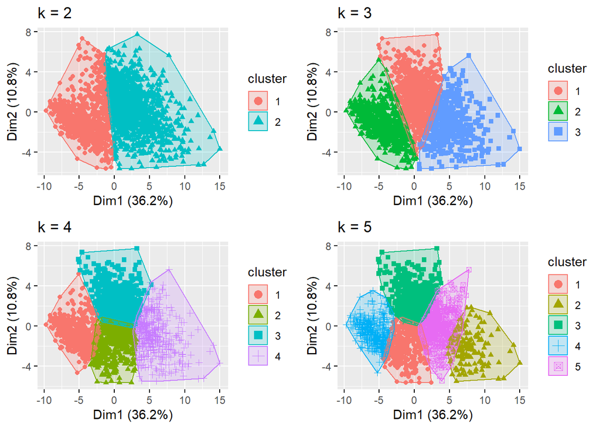

```r
gk2 <- kmeans(data_gk_int, centers = 2, nstart = 25)
gk3 <- kmeans(data_gk_int, centers = 3, nstart = 25)
gk4 <- kmeans(data_gk_int, centers = 4, nstart = 25)
gk5 <- kmeans(data_gk_int, centers = 5, nstart = 25)

# plots to compare
gkp1 <- fviz_cluster(gk2, geom = "point",  data = data_gk_int) + ggtitle("k = 2")
gkp2 <- fviz_cluster(gk3, geom = "point",  data = data_gk_int) + ggtitle("k = 3")
gkp3 <- fviz_cluster(gk4, geom = "point",  data = data_gk_int) + ggtitle("k = 4")
gkp4 <- fviz_cluster(gk5, geom = "point",  data = data_gk_int) + ggtitle("k = 5")

library(gridExtra)
grid.arrange(gkp1, gkp2, gkp3, gkp4, nrow = 2)
```

## **Determine the Number of Clusters**

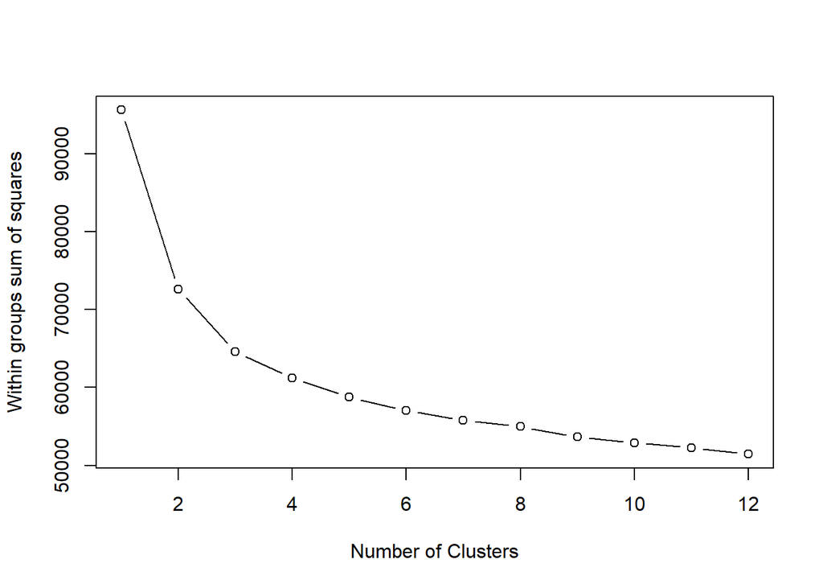

```r
# Determine number of clusters
wss <- (nrow(data_gk_int)-1)*sum(apply(data_gk_int,2,var))

for (i in 2:12) wss[i] <- sum(kmeans(data_gk_int,
                                     centers=i)$withinss)
plot(1:12, wss, type="b", xlab="Number of Clusters",ylab="Within groups sum of squares")
```

## **Checking the Prediction Strength - Goalkeepers**

```r
prediction.strength(data_gk_int, Gmin=2, Gmax=15, M=10,cutoff=0.8)
```

```
## Prediction strength
## Clustering method:  kmeans
## Maximum number of clusters:  15
## Resampled data sets:  10
## Mean pred.str. for numbers of clusters:  1 0.9465497 0.8432161 0.5933725 0.5177097 0.4696646 0.4155968 0.337572 0.3162195 0.3031324 0.303777 0.2817019 0.2539696 0.233146 0.2034054
## Cutoff value:  0.8
## Largest number of clusters better than cutoff:  3
```

## **Output of the K-Means - Goalkeepers**

```r
#use the output of kmeans
gk3$centers
```

```
##          age   height_cm   weight_kg     overall  potential
## 1  0.2722008  0.02397076  0.07642374 -0.07399651 -0.3579285
## 2 -0.8056819 -0.12273409 -0.30715291 -0.85725102 -0.2796168
## 3  0.6092431  0.12395932  0.28095721  1.29565980  1.0169297
##   international_reputation   weak_foot   gk_diving gk_handling gk_kicking
## 1               -0.2350217 -0.06479749 -0.09311223  -0.1257872 -0.1234589
## 2               -0.2444925 -0.11650054 -0.79456140  -0.7315079 -0.6834791
## 3                0.7504065  0.27354667  1.24457994   1.2171482  1.1477927
##   gk_reflexes   gk_speed gk_positioning attacking_crossing
## 1 -0.08862617  0.3399101     -0.0388205          0.2646941
## 2 -0.79693478 -0.9586043     -0.8238856         -0.4995433
## 3  1.23981494  0.6963138      1.1877283          0.2069570
##   attacking_finishing attacking_heading_accuracy attacking_short_passing
## 1           0.5003257                  0.2688590              0.09051013
## 2          -0.9545552                 -0.4840682             -0.49828966
```

[output cut: 41 more lines]

# **Cluster Analysis for Outfield Players**

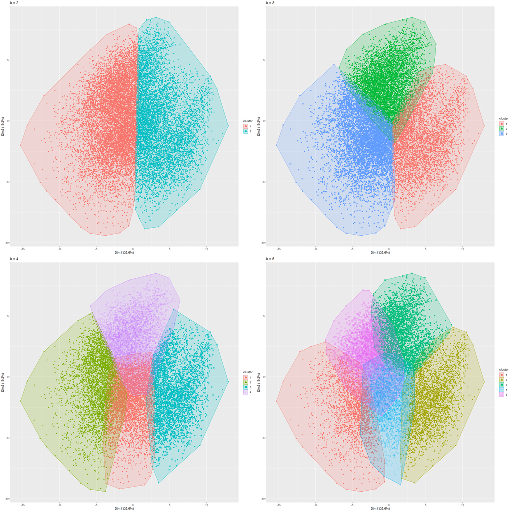

```r
ok2 <- kmeans(data_outfield_int, centers = 2, nstart = 25)
ok3 <- kmeans(data_outfield_int, centers = 3, nstart = 25)
ok4 <- kmeans(data_outfield_int, centers = 4, nstart = 25)
ok5 <- kmeans(data_outfield_int, centers = 5, nstart = 25)

# plots to compare
op1 <- fviz_cluster(ok2, geom = "point",  data = data_outfield_int) + ggtitle("k = 2")
op2 <- fviz_cluster(ok3, geom = "point",  data = data_outfield_int) + ggtitle("k = 3")
op3 <- fviz_cluster(ok4, geom = "point",  data = data_outfield_int) + ggtitle("k = 4")
op4 <- fviz_cluster(ok5, geom = "point",  data = data_outfield_int) + ggtitle("k = 5")

library(gridExtra)
grid.arrange(op1, op2, op3, op4, nrow = 2)
```

## **Determine the Number of Clusters - Outfield Players**

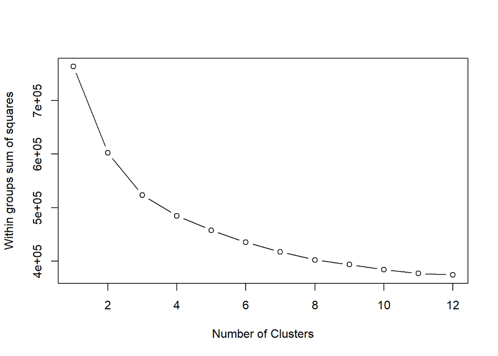

```r
# Determine number of clusters
wss_o <- (nrow(data_outfield_int)-1)*sum(apply(data_outfield_int,2,var))

for (i in 2:12) wss_o[i] <- sum(kmeans(data_outfield_int,
                                     centers=i)$withinss)
plot(1:12, wss_o, type="b", xlab="Number of Clusters",ylab="Within groups sum of squares")
```

## **Checking the Prediction Strength - Outfiled Players**

```r
prediction.strength(data_outfield_int, Gmin=2, Gmax=15, M=10,cutoff=0.8)
```

```
## Prediction strength
## Clustering method:  kmeans
## Maximum number of clusters:  15
## Resampled data sets:  10
## Mean pred.str. for numbers of clusters:  1 0.9557498 0.9313265 0.7640775 0.5269017 0.628195 0.4823138 0.6050884 0.4981196 0.4508408 0.3644348 0.3822084 0.334616 0.339305 0.2876533
## Cutoff value:  0.8
## Largest number of clusters better than cutoff:  3
```

## **Output of the K-Means - Outfield Players**

```r
#use the output of kmeans
ok3$centers
```

```
##           age  height_cm   weight_kg    overall  potential
## 1 -0.08568948  0.5346909  0.41946219 -0.3798785 -0.3049445
## 2 -0.42969900 -0.3353175 -0.37083635 -0.5326929 -0.2225367
## 3  0.45351852 -0.1524315 -0.02391674  0.7925551  0.4541936
##   international_reputation   weak_foot       pace   shooting    passing
## 1               -0.1971186 -0.37270635 -0.6383253 -1.1528294 -0.8197510
## 2               -0.2618142  0.04421257  0.3437641  0.3439705 -0.2548250
## 3                0.3982977  0.27446737  0.2321643  0.6650429  0.9161684
##    dribbling  defending     physic attacking_crossing attacking_finishing
## 1 -1.0279982  0.6420237  0.3122345         -0.7007539          -1.1229190
## 2  0.1232610 -1.0483196 -0.7949969         -0.1831150           0.4803348
## 3  0.7558693  0.3900735  0.4428148          0.7523592           0.5188326
##   attacking_heading_accuracy attacking_short_passing attacking_volleys
## 1                  0.2615464              -0.5857615        -1.0113119
## 2                 -0.5048306              -0.3728760         0.2651309
```

[output cut: 37 more lines]

### **Hierarchical Clustering**

# Defination

In data mining and statistics, hierarchical clustering (also called hierarchical cluster analysis or HCA) is a method of cluster analysis which seeks to build a hierarchy of clusters.

Strategies for hierarchical clustering generally fall into two types:

1. Agglomerative: This is a “bottom-up” approach: each observation starts in its own cluster, and pairs of clusters are merged as one moves up the hierarchy.
2. Divisive: This is a “top-down” approach: all observations start in one cluster, and splits are performed recursively as one moves down the hierarchy.

In general, the merges and splits are determined in a greedy manner. The results of hierarchical clustering[2] are usually presented in a dendrogram.

More Information can be found on [**Wikipedia**](https://en.wikipedia.org/wiki/Hierarchical_clustering)

# **Hierarchical Clustering Analysis for Goalkeepers**

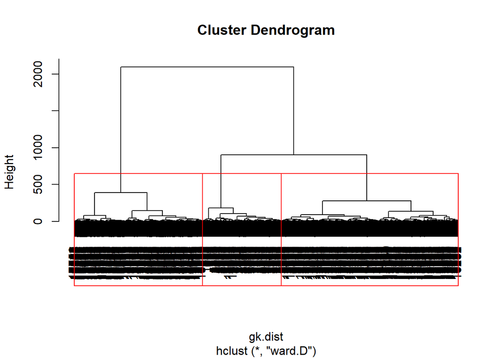

```r
#Wards Method or Hierarchical clustering
#Calculate the distance matrix
gk.dist = dist(data_gk_int)
#Obtain clusters using the Wards method
gk.hclust = hclust(gk.dist, method = "ward")

plot(gk.hclust)

rect.hclust(hclust(gk.dist, method = "ward"), h = 500)
```

# **Hierarchical Clustering Analysis for Outfileld Players**

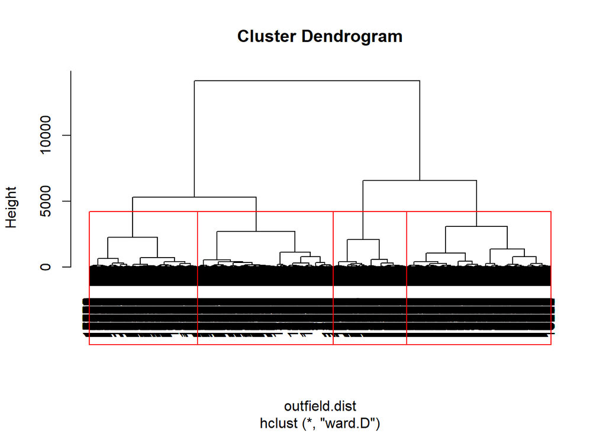

```r
#Wards Method or Hierarchical clustering
#Calculate the distance matrix
outfield.dist = dist(data_outfield_int)
#Obtain clusters using the Wards method
outfield.hclust = hclust(outfield.dist, method = "ward")

plot(outfield.hclust)

rect.hclust(hclust(outfield.dist, method = "ward"), h = 4000)
```